# R Markdown

## R Notebook

An R Notebook is a special execution mode of R Markdown with two characteristics that make it very useful for communicating resultsfrom https://www.r-bloggers.com/communicating-results-with-r-markdown/:

- Rendering a preview of an R Notebook does not execute R code, making it computationally convenient to create reports during or after interactive analyses.
- R Notebooks have an embedded copy of the source code, making it convenient for others to examine your work.

## Times to use R Markdown

| PROBLEM | COMMON TOOL | BETTER TOOL |
| --- | --- | --- |
| Share reports and presentations | Microsoft Office | R Markdown |
| Summarize and share your interactive analyses | R Scripts | R Notebooks |

## R Markdown - hype check…

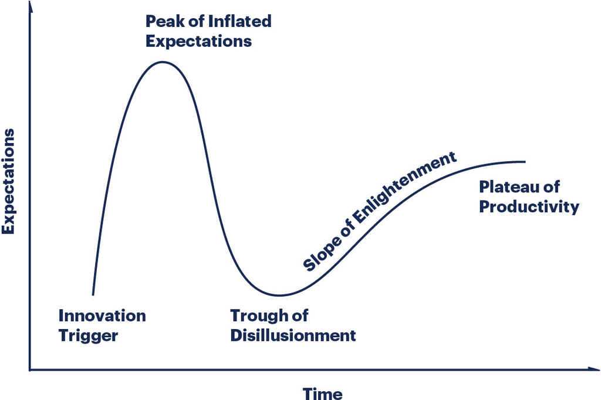

## R Markdown - Key limitations

- Tables
  - New packages improve this all the time
  - e.g. `arsenal` (+ `broom`)
- How does this fit into a typical paper writing workflow?

[figure not shown]

## Any questions???

- Slides are available at:
  - Slides available at GitHub:
  - https://github.com/Chris-M-P/Rmarkdown

### Useful links

- RStudio R Markdown resources - https://rmarkdown.rstudio.com/
- *R Markdown: The Definitive Guide* - [link](https://bookdown.org/yihui/rmarkdown/)
- R Markdown cheatsheet - available from RStudio:
  - *Help > Cheatsheets > R Markdown Cheat Sheet*
- Stackoverflow `Rmarkdown` tag - https://stackoverflow.com/questions/tagged/r-markdown